# Ejercicio 1: Tidyverse

Juan Barriola y Sofía Perini

12 de Septiembre de 2020

```r
#Librerias
library(tidyverse)
library(lubridate)
?options
```

### Dólar

1. Leer el dataset

Realizamos la lectura de los datasets y miramos su estructura

```r
dolar = read_csv(file='~/EEA-2020/Fuentes/dolar_oficial_ambito.csv')
glimpse(dolar)
```

```
## Observations: 1,268
## Variables: 3
## $ fecha  <chr> "05-08-2020", "04-08-2020", "03-08-2020", "31-07-2020", "…
## $ compra <dbl> 71.89, 71.69, 71.64, 71.39, 71.27, 71.08, 71.10, 71.00, 7…
## $ venta  <dbl> 76.89, 76.69, 76.64, 76.39, 76.27, 76.08, 76.10, 76.00, 7…
```

2. Crear la variable cotización_promedio, realizando el promedio entre compra y venta para cada día

```r
dolar = dolar %>% mutate(cotizacion_promedio = (compra + venta)/2)
glimpse(dolar)
```

```
## Observations: 1,268
## Variables: 4
## $ fecha               <chr> "05-08-2020", "04-08-2020", "03-08-2020", "3…
## $ compra              <dbl> 71.89, 71.69, 71.64, 71.39, 71.27, 71.08, 71…
## $ venta               <dbl> 76.89, 76.69, 76.64, 76.39, 76.27, 76.08, 76…
## $ cotizacion_promedio <dbl> 74.39, 74.19, 74.14, 73.89, 73.77, 73.58, 73…
```

3. Convertir la variable fecha de string a datetime. Crear las variables de año, mes y día

```r
dolar = dolar %>% mutate(fecha=dmy(fecha), año=year(fecha), mes=month(fecha),
                         dia=day(fecha))
glimpse(dolar)
```

```
## Observations: 1,268
## Variables: 7
## $ fecha               <date> 2020-08-05, 2020-08-04, 2020-08-03, 2020-07…
## $ compra              <dbl> 71.89, 71.69, 71.64, 71.39, 71.27, 71.08, 71…
## $ venta               <dbl> 76.89, 76.69, 76.64, 76.39, 76.27, 76.08, 76…
## $ cotizacion_promedio <dbl> 74.39, 74.19, 74.14, 73.89, 73.77, 73.58, 73…
## $ año                 <dbl> 2020, 2020, 2020, 2020, 2020, 2020, 2020, 20…
## $ mes                 <dbl> 8, 8, 8, 7, 7, 7, 7, 7, 7, 7, 7, 7, 7, 7, 7,…
## $ dia                 <int> 5, 4, 3, 31, 30, 29, 28, 27, 24, 24, 23, 22,…
```

4. Graficar la evolución diaria de la cotización promedio

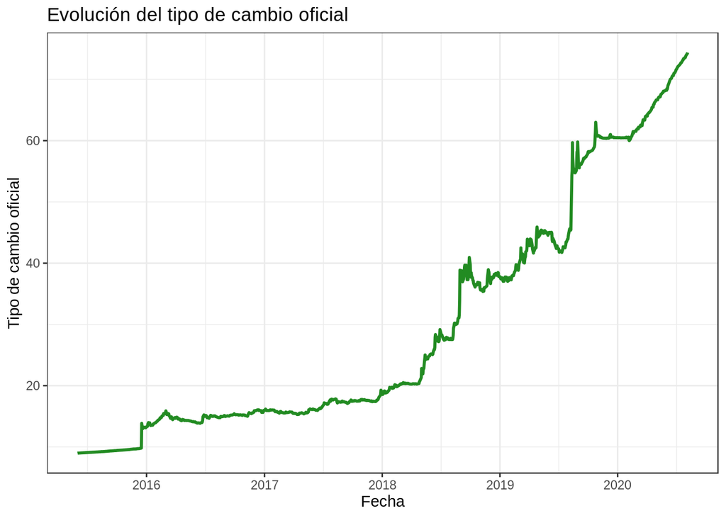

```r
ggplot(dolar, aes(x=fecha, y=cotizacion_promedio,)) +
  geom_line(color="forestgreen", size=1) +
  labs(x="Fecha", y="Tipo de cambio oficial", title="Evolución del tipo de cambio oficial")+
  theme_bw()
```

5. Crear un dataframe con la mediana de la cotización promedio para cada año y mes (esta será la cotización mensual del dólar oficial)

```r
dolar_mensual = dolar %>% group_by(año, mes) %>%
  summarise(cotizacion_mensual = median(cotizacion_promedio)) %>%
  ungroup() # Evitar que mantenga el grupo para otras operaciones
glimpse(dolar_mensual)
```

```
## Observations: 63
## Variables: 3
## $ año                <dbl> 2015, 2015, 2015, 2015, 2015, 2015, 2015, 201…
## $ mes                <dbl> 6, 7, 8, 9, 10, 11, 12, 1, 2, 3, 4, 5, 6, 7, …
## $ cotizacion_mensual <dbl> 9.0350, 9.1350, 9.2350, 9.3550, 9.4750, 9.625…
```

### IPC

1. Leer el dataset

```r
ipc = read_csv('~/EEA-2020/Fuentes/ipc-mensual.csv')
glimpse(ipc)
```

```
## Observations: 4
## Variables: 44
## $ Apertura <chr> "Nivel general", "Estacional", "Núcleo", "Regulados"
## $ `Dec-16` <dbl> 100, 100, 100, 100
## $ `Jan-17` <dbl> 101.6, 101.7, 101.5, 101.8
## $ `Feb-17` <dbl> 103.7, 102.3, 103.2, 105.9
## $ `Mar-17` <dbl> 106.1, 104.8, 105.2, 110.0
## $ `Apr-17` <dbl> 109.0, 108.2, 107.4, 114.5
## $ `May-17` <dbl> 110.5, 109.1, 109.2, 115.7
## $ `Jun-17` <dbl> 111.8, 110.1, 110.7, 116.7
## $ `Jul-17` <dbl> 113.8, 110.6, 112.6, 119.4
## $ `Aug-17` <dbl> 115.4, 111.8, 114.2, 121.1
## $ `Sep-17` <dbl> 117.6, 116.2, 116.1, 123.2
## $ `Oct-17` <dbl> 119.4, 119.0, 117.6, 125.3
## $ `Nov-17` <dbl> 121.0, 121.1, 119.1, 127.1
```

[output cut: 31 more lines]

2. Modificar el dataset para que cumpla con la definición de tidy data: cada variable debe ser una columna (Apertura, Fecha e Indice). *Pista*: piensen si tienen que usar `pivot_longer` o `pivot_wider`

```r
ipc = ipc %>% pivot_longer(-Apertura, names_to = "fecha", values_to = "indice")
glimpse(ipc)
```

```
## Observations: 172
## Variables: 3
## $ Apertura <chr> "Nivel general", "Nivel general", "Nivel general", "Niv…
## $ fecha    <chr> "Dec-16", "Jan-17", "Feb-17", "Mar-17", "Apr-17", "May-…
## $ indice   <dbl> 100.0, 101.6, 103.7, 106.1, 109.0, 110.5, 111.8, 113.8,…
```

3. Crear las variables fecha, año, mes y día

```r
ipc = ipc %>% mutate(fecha=ymd(parse_date_time(fecha, orders = 'my')),
                    año=year(fecha), mes=month(fecha))
glimpse(ipc)
```

```
## Observations: 172
## Variables: 5
## $ Apertura <chr> "Nivel general", "Nivel general", "Nivel general", "Niv…
## $ fecha    <date> 2016-12-01, 2017-01-01, 2017-02-01, 2017-03-01, 2017-0…
## $ indice   <dbl> 100.0, 101.6, 103.7, 106.1, 109.0, 110.5, 111.8, 113.8,…
## $ año      <dbl> 2016, 2017, 2017, 2017, 2017, 2017, 2017, 2017, 2017, 2…
## $ mes      <dbl> 12, 1, 2, 3, 4, 5, 6, 7, 8, 9, 10, 11, 12, 1, 2, 3, 4, …
```

4. Graficar la evolución del nivel general del IPC

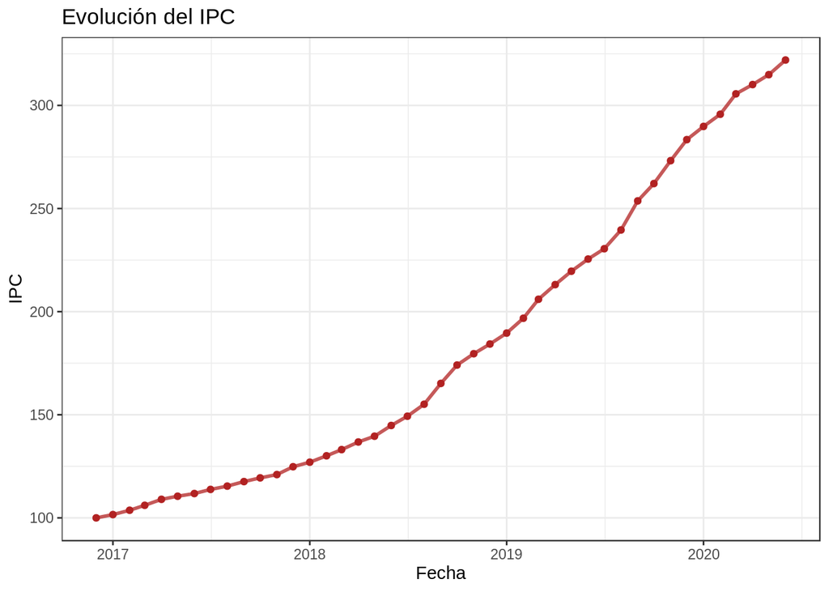

```r
ipc %>% filter(Apertura== "Nivel general") %>%
ggplot(., aes(x= fecha, y = indice)) +
  geom_point(color="firebrick")+
  geom_line(size= 1,alpha=0.75, color = "firebrick")+
  labs(x="Fecha", y="IPC", title="Evolución del IPC")+
  theme_bw()
```

5. Graficar la evolución de los 4 grupos

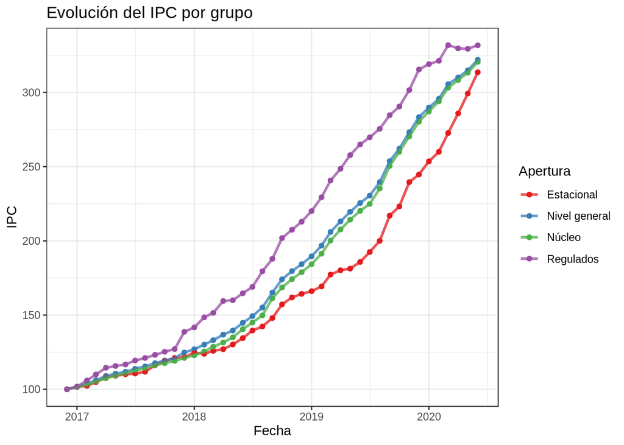

```r
ggplot(ipc, aes(x= fecha, y = indice, group = Apertura, color = Apertura )) +
  geom_point()+
  geom_line(size=1,alpha=0.75)+
  labs(x="Fecha", y="IPC", title="Evolución del IPC por grupo")+
  theme_bw()+
  scale_color_brewer(palette = "Set1")
```

### IPC y Dolar

1. Realizar un join de ambos conjuntos de datos (dólar mensual e IPC) de manera que queden los meses para los cuáles hay datos de ambas variables

Utilizamos un inner join ya que solo queremos quedarnos con los meses para los cuales tenemos información del IPC y del dólar.

```r
ipc_dolar = ipc %>% inner_join(dolar_mensual, by=c('año', 'mes'))
glimpse(ipc_dolar)
```

```
## Observations: 172
## Variables: 6
## $ Apertura           <chr> "Nivel general", "Nivel general", "Nivel gene…
## $ fecha              <date> 2016-12-01, 2017-01-01, 2017-02-01, 2017-03-…
## $ indice             <dbl> 100.0, 101.6, 103.7, 106.1, 109.0, 110.5, 111…
## $ año                <dbl> 2016, 2017, 2017, 2017, 2017, 2017, 2017, 201…
## $ mes                <dbl> 12, 1, 2, 3, 4, 5, 6, 7, 8, 9, 10, 11, 12, 1,…
## $ cotizacion_mensual <dbl> 15.930, 16.005, 15.740, 15.625, 15.500, 15.69…
```

2. Crear el indice de evolución del dólar con base en Diciembre de 2016. La fómula de calculo a utilizar es: $Indice_t = \frac{cotizacion_t * 100}{cotizacion_{dic2016}}$

```r
cotizacion_mes_base = dolar_mensual %>%
  filter(mes==12, año==2016) %>%
  pull(cotizacion_mensual) # Pull nos permite seleccionar el valor como un número, select lo traería como un dataframe

ipc_dolar = ipc_dolar %>% mutate(indice_dolar = cotizacion_mensual * 100 / cotizacion_mes_base)
```

3. Calcular la media, el desvío estándar, la mediana y el rango del indice del dólar y del IPC General para cada uno de los años

```r
resumen=ipc_dolar %>% filter(Apertura=="Nivel general") %>%
              group_by(año) %>%
              summarise(dolar_promedio=mean(indice_dolar),
                        desvio_dolar=sd(indice_dolar),
                        mediana_dolar=median(indice_dolar),
                        rango_dolar=max(indice_dolar)-min(indice_dolar),
                        ipc_promedio=mean(indice),
                        desvio_ipc=sd(indice),
                        mediana_ipc=median(indice),
                        rango_ipc=max(indice)-min(indice))

resumen
```

| año | dolar_promedio | desvio_dolar | mediana_dolar | rango_dolar | ipc_promedio | desvio_ipc | mediana_ipc | rango_ipc |
| --- | --- | --- | --- | --- | --- | --- | --- | --- |
| 2016 | 100.0000 | NA | 100.0000 | 0.00000 | 100.0000 | NA | 100.00 | 0.0 |
| 2017 | 104.3262 | 5.64897 | 104.5198 | 13.49655 | 112.8917 | 7.131041 | 112.80 | 23.2 |
| 2018 | 176.7865 | 47.21518 | 172.2693 | 120.33898 | 151.5833 | 19.956718 | 147.05 | 57.3 |
| 2019 | 304.7957 | 55.83864 | 278.2721 | 144.47583 | 232.7583 | 30.204499 | 228.00 | 93.8 |
| 2020 | 404.7395 | 24.63747 | 401.5537 | 60.89140 | 306.3500 | 11.999792 | 307.85 | 32.2 |

4. Graficar la evolución del indice del dólar y del nivel general del IPC

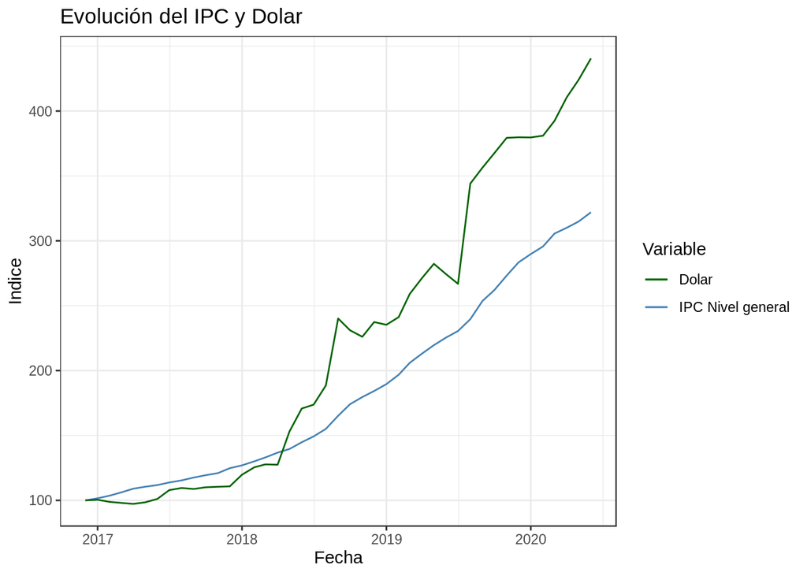

```r
ggplot()+
  geom_line(data = ipc_dolar %>% filter(Apertura=="Nivel general"),aes(x=fecha,y=indice, color ="IPC Nivel general"))+
  geom_line(data = ipc_dolar,aes(fecha,indice_dolar, color ="Dolar"))+
  scale_colour_manual("Variable",values=c("darkgreen", "steelblue"))+
  labs(x="Fecha", y="Indice", title="Evolución del IPC y Dolar")+
  theme_bw()
```

5. Graficar la evolución del dólar y de los 4 grupos de IPC

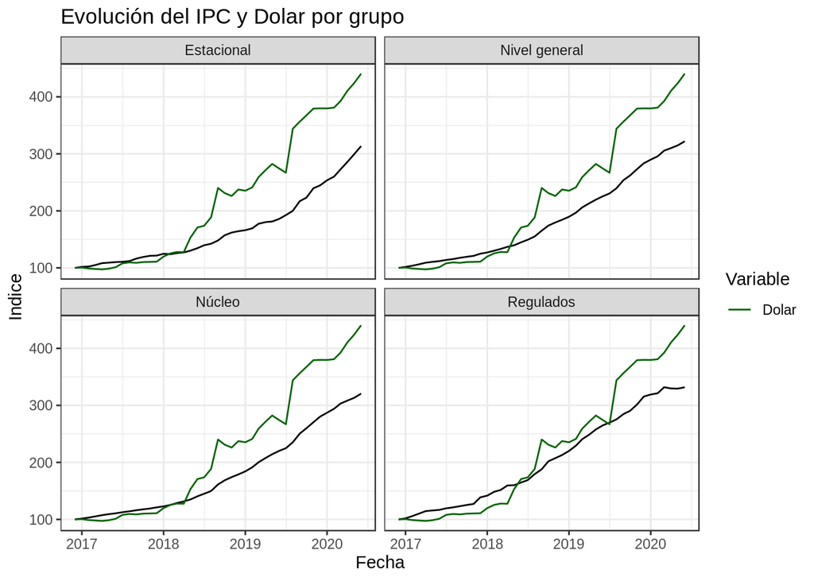

```r
ggplot()+
  geom_line(data = ipc_dolar,aes(x=fecha,y=indice))+
  geom_line(data = ipc_dolar,aes(x=fecha,y=indice_dolar, color ="Dolar"))+
  scale_colour_manual("Variable",values=c("darkgreen"))+
  theme_bw()+
  labs(x="Fecha", y="Indice", title="Evolución del IPC y Dolar por grupo")+
  facet_wrap(.~Apertura)
```